# Graph Construction and Analysis with NetworkX

Author

Peter Youyun Zheng

Published

April 21, 2024

# Introduction

This will be for developing the code to: 1. take in all bedpe in a directory, concatenate them 2. normalize continuous features, one hot encode categorical features 3. output a graph dataset for each cluster of every patient

```python
import os
import pandas as pd
import numpy as np
import networkx as nx
import matplotlib.pyplot as plt
from tqdm import tqdm
import pickle
# local vs UGER
if os.path.expanduser('~') in ["/Users/youyun", "/Users/youyunzheng"]:
    # in a local mac, the home directory is usuaully at '/Users/[username]'
    workdir = os.path.expanduser('~')+"/Documents/HMS/PhD/beroukhimlab/broad_mount/"
else:
    # in dipg or uger, the home directory is usuaully at '/home/unix/[username]'
    workdir = "/xchip/beroukhimlab/"
```

# Load Data

In the real code, there will be a input variable of a bedpe directory `workdir + "youyun/complexSV/data/bedpe_test"`

```python
# load data
bedpe_dir = workdir + "youyun/complexSV/data/bedpe_test/"
bedpe_files = [workdir + "youyun/complexSV/data/bedpe_test/" +  f for f in os.listdir(bedpe_dir) if f.endswith('annotated.bedpe')]
# read in all the bedpe files and concatenate them into one variable
bedpe = pd.concat([pd.read_csv(f, sep='\t') for f in bedpe_files[0:2]])
```

# Feature Scaling

`'seqnames_breakend1', 'start_breakend1', 'end_breakend1', 'seqnames_breakend2', 'start_breakend2', 'end_breakend2', 'Sample', 'SV_ID', 'cnt_type_breakend1', 'cnt_type_breakend2', 'cluster_ID', 'cluster_size', 'footprint_ID_low', 'footprint_ID_high', 'span_low', 'span_high', 'pval', 'ins_seq', 'ins_len', 'mh_seq', 'mh_len', 'N_ALT', 'N_ALT_RP', 'N_ALT_SR', 'svclass', 'REF_breakend1', 'REF_breakend2', 'ALT_breakend1', 'ALT_breakend2', 'ID_breakend1', 'ID_breakend2', 'rep_time_breakend1', 'gc_breakend1', 'gene_density_breakend1', 'dist_to_line_breakend1', 'dist_to_sine_breakend1', 'dist_to_ltr_breakend1', 'dist_to_dna_breakend1', 'dist_to_sr_breakend1', 'dist_to_TAD_breakend1', 'dist_to_telomere_breakend1', 'dist_to_centromere_breakend1', 'total_cn_breakend1', 'major_cn_breakend1', 'minor_cn_breakend1', 'rep_time_breakend2', 'gc_breakend2', 'gene_density_breakend2', 'dist_to_line_breakend2', 'dist_to_sine_breakend2', 'dist_to_ltr_breakend2', 'dist_to_dna_breakend2', 'dist_to_sr_breakend2', 'dist_to_TAD_breakend2', 'dist_to_telomere_breakend2', 'dist_to_centromere_breakend2', 'total_cn_breakend2', 'major_cn_breakend2', 'minor_cn_breakend2'`

In detail, the features to be kept and how they should be scaled are:

1. ‘seqnames_breakend1’, ‘seqnames_breakend2’: one hot encode
2. ‘start_breakend1’, ‘start_breakend2’: normalize by the length of chr1: 249250621
3. ‘cnt_type_breakend1’, ‘cnt_type_breakend2’: one hot encode
4. ‘ins_len’, ‘mh_len’, ‘N_ALT’, ‘N_ALT_RP’, ‘N_ALT_SR’: log 10 transform (x+1) -> normalize
5. ‘svclass’: one hot encode
6. ‘rep_time_breakend1’, ‘rep_time_breakend2’: NA to 0 -> minmax normalize since there are negative values
7. ‘gc_breakend1’, ‘gc_breakend2’: NA to 100 -> normalize
8. ‘gene_density_breakend1’, ‘gene_density_breakend2’: log 10 transform (x+1) -> normalize
9. ‘dist_to_line_breakend1’, ‘dist_to_line_breakend2’, ‘dist_to_sine_breakend1’, ‘dist_to_sine_breakend2’, ‘dist_to_ltr_breakend1’, ‘dist_to_ltr_breakend2’, ‘dist_to_dna_breakend1’, ‘dist_to_dna_breakend2’, ‘dist_to_sr_breakend1’, ‘dist_to_sr_breakend2’, ‘dist_to_TAD_breakend1’, ‘dist_to_TAD_breakend2’, ‘dist_to_telomere_breakend1’, ‘dist_to_telomere_breakend2’, ‘dist_to_centromere_breakend1’, ‘dist_to_centromere_breakend2’: normalize
10. ‘total_cn_breakend1’, ‘major_cn_breakend1’, ‘minor_cn_breakend1’, ‘total_cn_breakend2’, ‘major_cn_breakend2’, ‘minor_cn_breakend2’: log2 transform (x+1) -> normalize

Columns to keep for downstream analysis:

11. ‘cluster_ID’
12. ‘cluster_size’
13. ‘Sample’

```python
# one hot encode
scaled_bedpe = pd.get_dummies(bedpe[['seqnames_breakend1', 'seqnames_breakend2', 'cnt_type_breakend1', 'cnt_type_breakend2', 'svclass']])
# normalize
scaled_bedpe['start_breakend1'] = bedpe['start_breakend1']/249250621
scaled_bedpe['start_breakend2'] = bedpe['start_breakend2']/249250621

scaled_bedpe['ins_len'] = np.log10(bedpe['ins_len']+1)/np.log10(bedpe['ins_len']+1).max()
scaled_bedpe['mh_len'] = np.log10(bedpe['mh_len']+1)/np.log10(bedpe['mh_len']+1).max()
scaled_bedpe['N_ALT'] = np.log10(bedpe['N_ALT']+1)/np.log10(bedpe['N_ALT']+1).max()
scaled_bedpe['N_ALT_RP'] = np.log10(bedpe['N_ALT_RP']+1)/np.log10(bedpe['N_ALT_RP']+1).max()
scaled_bedpe['N_ALT_SR'] = np.log10(bedpe['N_ALT_SR']+1)/np.log10(bedpe['N_ALT_SR']+1).max()

scaled_bedpe['rep_time_breakend1'] = bedpe['rep_time_breakend1'].fillna(0)
scaled_bedpe['rep_time_breakend2'] = bedpe['rep_time_breakend2'].fillna(0)
scaled_bedpe['rep_time_breakend1'] = (bedpe['rep_time_breakend1']-bedpe['rep_time_breakend1'].min())/(bedpe['rep_time_breakend1'].max()-bedpe['rep_time_breakend1'].min())
scaled_bedpe['rep_time_breakend2'] = (bedpe['rep_time_breakend2']-bedpe['rep_time_breakend2'].min())/(bedpe['rep_time_breakend2'].max()-bedpe['rep_time_breakend2'].min())

scaled_bedpe['gc_breakend1'] = bedpe['gc_breakend1'].fillna(100)/100
scaled_bedpe['gc_breakend2'] = bedpe['gc_breakend2'].fillna(100)/100

scaled_bedpe['gene_density_breakend1'] = np.log10(bedpe['gene_density_breakend1']+1)/np.log10(bedpe['gene_density_breakend1']+1).max()
scaled_bedpe['gene_density_breakend2'] = np.log10(bedpe['gene_density_breakend2']+1)/np.log10(bedpe['gene_density_breakend2']+1).max()

scaled_bedpe['dist_to_line_breakend1'] = bedpe['dist_to_line_breakend1']/bedpe['dist_to_line_breakend1'].max()
scaled_bedpe['dist_to_line_breakend2'] = bedpe['dist_to_line_breakend2']/bedpe['dist_to_line_breakend2'].max()
scaled_bedpe['dist_to_sine_breakend1'] = bedpe['dist_to_sine_breakend1']/bedpe['dist_to_sine_breakend1'].max()
scaled_bedpe['dist_to_sine_breakend2'] = bedpe['dist_to_sine_breakend2']/bedpe['dist_to_sine_breakend2'].max()
scaled_bedpe['dist_to_ltr_breakend1'] = bedpe['dist_to_ltr_breakend1']/bedpe['dist_to_ltr_breakend1'].max()
scaled_bedpe['dist_to_ltr_breakend2'] = bedpe['dist_to_ltr_breakend2']/bedpe['dist_to_ltr_breakend2'].max()
scaled_bedpe['dist_to_dna_breakend1'] = bedpe['dist_to_dna_breakend1']/bedpe['dist_to_dna_breakend1'].max()
scaled_bedpe['dist_to_dna_breakend2'] = bedpe['dist_to_dna_breakend2']/bedpe['dist_to_dna_breakend2'].max()
scaled_bedpe['dist_to_sr_breakend1'] = bedpe['dist_to_sr_breakend1']/bedpe['dist_to_sr_breakend1'].max()
scaled_bedpe['dist_to_sr_breakend2'] = bedpe['dist_to_sr_breakend2']/bedpe['dist_to_sr_breakend2'].max()
scaled_bedpe['dist_to_TAD_breakend1'] = bedpe['dist_to_TAD_breakend1']/bedpe['dist_to_TAD_breakend1'].max()
scaled_bedpe['dist_to_TAD_breakend2'] = bedpe['dist_to_TAD_breakend2']/bedpe['dist_to_TAD_breakend2'].max()
scaled_bedpe['dist_to_telomere_breakend1'] = bedpe['dist_to_telomere_breakend1']/bedpe['dist_to_telomere_breakend1'].max()
scaled_bedpe['dist_to_telomere_breakend2'] = bedpe['dist_to_telomere_breakend2']/bedpe['dist_to_telomere_breakend2'].max()
scaled_bedpe['dist_to_centromere_breakend1'] = bedpe['dist_to_centromere_breakend1']/bedpe['dist_to_centromere_breakend1'].max()
scaled_bedpe['dist_to_centromere_breakend2'] = bedpe['dist_to_centromere_breakend2']/bedpe['dist_to_centromere_breakend2'].max()

scaled_bedpe['total_cn_breakend1'] = np.log2(bedpe['total_cn_breakend1']+1)/np.log2(bedpe['total_cn_breakend1']+1).max()
scaled_bedpe['major_cn_breakend1'] = np.log2(bedpe['major_cn_breakend1']+1)/np.log2(bedpe['major_cn_breakend1']+1).max()
scaled_bedpe['minor_cn_breakend1'] = np.log2(bedpe['minor_cn_breakend1']+1)/np.log2(bedpe['minor_cn_breakend1']+1).max()
scaled_bedpe['total_cn_breakend2'] = np.log2(bedpe['total_cn_breakend2']+1)/np.log2(bedpe['total_cn_breakend2']+1).max()
scaled_bedpe['major_cn_breakend2'] = np.log2(bedpe['major_cn_breakend2']+1)/np.log2(bedpe['major_cn_breakend2']+1).max()
scaled_bedpe['minor_cn_breakend2'] = np.log2(bedpe['minor_cn_breakend2']+1)/np.log2(bedpe['minor_cn_breakend2']+1).max()

scaled_bedpe['cluster_ID'] = bedpe['cluster_ID']
scaled_bedpe['cluster_size'] = bedpe['cluster_size']
scaled_bedpe['Sample'] = bedpe['Sample']
```

Reviewing the scaled features and how well the scaling worked:

```python
print(scaled_bedpe.columns)
print('Starting Positions')
print(scaled_bedpe[['start_breakend1', 'start_breakend2']].describe())
print('Insertion Lengths, Microhomology Lengths, Number of ALTs, Number of ALTs from RP, Number of ALTs from SR')
print(scaled_bedpe[['ins_len', 'mh_len', 'N_ALT', 'N_ALT_RP', 'N_ALT_SR']].describe())
print('Replication Time')
print(scaled_bedpe[['rep_time_breakend1', 'rep_time_breakend2']].describe())
print('GC Content')
print(scaled_bedpe[['gc_breakend1', 'gc_breakend2']].describe())
print('Gene Density')
print(scaled_bedpe[['gene_density_breakend1', 'gene_density_breakend2']].describe())
print('Distances to Genomic Features')
print(scaled_bedpe[['dist_to_line_breakend1', 'dist_to_line_breakend2', 'dist_to_sine_breakend1', 'dist_to_sine_breakend2', 'dist_to_ltr_breakend1', 'dist_to_ltr_breakend2', 'dist_to_dna_breakend1', 'dist_to_dna_breakend2', 'dist_to_sr_breakend1', 'dist_to_sr_breakend2', 'dist_to_TAD_breakend1', 'dist_to_TAD_breakend2', 'dist_to_telomere_breakend1', 'dist_to_telomere_breakend2', 'dist_to_centromere_breakend1', 'dist_to_centromere_breakend2']].describe())
print('Copy Number')
print(scaled_bedpe[['total_cn_breakend1', 'major_cn_breakend1', 'minor_cn_breakend1', 'total_cn_breakend2', 'major_cn_breakend2', 'minor_cn_breakend2']].describe())
```

```
Index(['seqnames_breakend1_1', 'seqnames_breakend1_10',
       'seqnames_breakend1_11', 'seqnames_breakend1_12',
       'seqnames_breakend1_13', 'seqnames_breakend1_14',
       'seqnames_breakend1_15', 'seqnames_breakend1_16',
       'seqnames_breakend1_17', 'seqnames_breakend1_18',
       'seqnames_breakend1_19', 'seqnames_breakend1_2',
       'seqnames_breakend1_20', 'seqnames_breakend1_21',
       'seqnames_breakend1_22', 'seqnames_breakend1_3', 'seqnames_breakend1_4',
       'seqnames_breakend1_5', 'seqnames_breakend1_6', 'seqnames_breakend1_7',
       'seqnames_breakend1_8', 'seqnames_breakend1_9', 'seqnames_breakend1_X',
       'seqnames_breakend2_1', 'seqnames_breakend2_10',
       'seqnames_breakend2_11', 'seqnames_breakend2_12',
       'seqnames_breakend2_13', 'seqnames_breakend2_14',
       'seqnames_breakend2_15', 'seqnames_breakend2_16',
       'seqnames_breakend2_17', 'seqnames_breakend2_18',
       'seqnames_breakend2_19', 'seqnames_breakend2_2',
       'seqnames_breakend2_20', 'seqnames_breakend2_21',
       'seqnames_breakend2_22', 'seqnames_breakend2_3', 'seqnames_breakend2_4',
       'seqnames_breakend2_5', 'seqnames_breakend2_6', 'seqnames_breakend2_7',
       'seqnames_breakend2_8', 'seqnames_breakend2_9', 'seqnames_breakend2_X',
       'cnt_type_breakend1_+', 'cnt_type_breakend1_-', 'cnt_type_breakend2_+',
       'cnt_type_breakend2_-', 'svclass_DEL', 'svclass_DUP', 'svclass_TRA',
       'svclass_h2hINV', 'svclass_t2tINV', 'start_breakend1',
       'start_breakend2', 'ins_len', 'mh_len', 'N_ALT', 'N_ALT_RP', 'N_ALT_SR',
       'rep_time_breakend1', 'rep_time_breakend2', 'gc_breakend1',
       'gc_breakend2', 'gene_density_breakend1', 'gene_density_breakend2',
       'dist_to_line_breakend1', 'dist_to_line_breakend2',
       'dist_to_sine_breakend1', 'dist_to_sine_breakend2',
       'dist_to_ltr_breakend1', 'dist_to_ltr_breakend2',
       'dist_to_dna_breakend1', 'dist_to_dna_breakend2',
       'dist_to_sr_breakend1', 'dist_to_sr_breakend2', 'dist_to_TAD_breakend1',
       'dist_to_TAD_breakend2', 'dist_to_telomere_breakend1',
       'dist_to_telomere_breakend2', 'dist_to_centromere_breakend1',
       'dist_to_centromere_breakend2', 'total_cn_breakend1',
       'major_cn_breakend1', 'minor_cn_breakend1', 'total_cn_breakend2',
       'major_cn_breakend2', 'minor_cn_breakend2', 'cluster_ID',
       'cluster_size', 'Sample'],
      dtype='object')
Starting Positions
       start_breakend1  start_breakend2
```

[output cut: 113 more lines]

```
min              0.000000            0.000000            0.000000
25%              0.290316            0.183169            0.000000
50%              0.366339            0.290316            0.430677
75%              0.549508            0.473486            0.430677
max              1.000000            1.000000            1.000000

       total_cn_breakend2  major_cn_breakend2  minor_cn_breakend2
count          435.000000          435.000000          435.000000
mean             0.428268            0.372882            0.320463
std              0.193045            0.229378            0.233162
min              0.000000            0.000000            0.000000
25%              0.288602            0.187902            0.000000
50%              0.364176            0.297817            0.386853
75%              0.511185            0.527507            0.386853
max              1.000000            1.000000            1.000000
```

# Graph Construction

The graph will be constructed as follows:

   Two nodes are connected if one of the breakends (a,b) of node A is downstream of one of the breakends (c,d) of node B breakend A is downstream of breakend B if:

   ```
   1.  cnt_type of breakend (a or b) is + and cnt_type of breakend (c or d) is - AND
       start of breakend (a or b) is lower than start of breakend (c or d)
   2.  cnt_type of breakend (a or b) is - and cnt_type of breakend (c or d) is + AND
       start of breakend (a or b) is higher than start of breakend (c or d)
   ```

```
                                  Sample  cluster_ID  cluster_size
24  efe4d5dd-fffb-41df-ab86-be06cc16646f           1           100
31  efe4d5dd-fffb-41df-ab86-be06cc16646f           3            11
61  efe4d5dd-fffb-41df-ab86-be06cc16646f          19            13
```

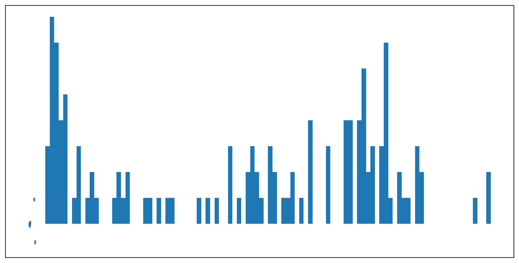

```python
# filter for clusters with more than 1 SV
clustered_bedpe = scaled_bedpe[scaled_bedpe['cluster_size']>10]
print(clustered_bedpe[['Sample','cluster_ID','cluster_size']].drop_duplicates())
# construct graph
G = nx.Graph()
# for each sample
for sample in tqdm(clustered_bedpe['Sample'].unique()):
    # get the bedpe for that sample
    sample_bedpe = clustered_bedpe[clustered_bedpe['Sample']==sample]
    # for each cluster
    for cluster in sample_bedpe['cluster_ID'].unique():
        # get the bedpe for that cluster
        cluster_bedpe = sample_bedpe[sample_bedpe['cluster_ID']==cluster]
        # for each row in the bedpe
        for i in range(cluster_bedpe.shape[0]):
            # adding in all info aside from the Sample, cluster_ID, and cluster_size
            nodal_features = cluster_bedpe.iloc[i].drop(['Sample', 'cluster_ID', 'cluster_size']).to_dict()
            # add the node to the graph
            G.add_node(
                cluster_bedpe.iloc[i]['Sample'] + '_' + str(cluster_bedpe.iloc[i]['cluster_ID']) + '_' + str(i),
                **nodal_features
            )
            # for each other row in the bedpe
            for j in range(i+1, cluster_bedpe.shape[0]):
                # checking if either of the breakends of node A is downstream of either of the breakends of node B
                # if the two nodes are connected
                if (
                    cluster_bedpe.iloc[i]['cnt_type_breakend1_+'] and
                    cluster_bedpe.iloc[j]['cnt_type_breakend2_-'] and
                    cluster_bedpe.iloc[i]['start_breakend1']<cluster_bedpe.iloc[j]['start_breakend2']
                ) or (
                    cluster_bedpe.iloc[i]['cnt_type_breakend1_-'] and
                    cluster_bedpe.iloc[j]['cnt_type_breakend2_+'] and
                    cluster_bedpe.iloc[i]['start_breakend1']>cluster_bedpe.iloc[j]['start_breakend2']
                ) or (
                    cluster_bedpe.iloc[i]['cnt_type_breakend2_+'] and
                    cluster_bedpe.iloc[j]['cnt_type_breakend1_-'] and
                    cluster_bedpe.iloc[i]['start_breakend2']<cluster_bedpe.iloc[j]['start_breakend1']
                ) or (
                    cluster_bedpe.iloc[i]['cnt_type_breakend2_-'] and
                    cluster_bedpe.iloc[j]['cnt_type_breakend1_+'] and
                    cluster_bedpe.iloc[i]['start_breakend2']>cluster_bedpe.iloc[j]['start_breakend1']
                ) or (
                    cluster_bedpe.iloc[i]['cnt_type_breakend1_+'] and
                    cluster_bedpe.iloc[j]['cnt_type_breakend1_-'] and
                    cluster_bedpe.iloc[i]['start_breakend1']<cluster_bedpe.iloc[j]['start_breakend1']
                ) or (
                    cluster_bedpe.iloc[i]['cnt_type_breakend1_-'] and
                    cluster_bedpe.iloc[j]['cnt_type_breakend1_+'] and
                    cluster_bedpe.iloc[i]['start_breakend1']>cluster_bedpe.iloc[j]['start_breakend1']
                ) or (
                    cluster_bedpe.iloc[i]['cnt_type_breakend2_+'] and
                    cluster_bedpe.iloc[j]['cnt_type_breakend2_-'] and
                    cluster_bedpe.iloc[i]['start_breakend2']<cluster_bedpe.iloc[j]['start_breakend2']
                ) or (
                    cluster_bedpe.iloc[i]['cnt_type_breakend2_-'] and
                    cluster_bedpe.iloc[j]['cnt_type_breakend2_+'] and
                    cluster_bedpe.iloc[i]['start_breakend2']>cluster_bedpe.iloc[j]['start_breakend2']
                ):
                    G.add_edge(
                        cluster_bedpe.iloc[i]['Sample'] + '_' + str(cluster_bedpe.iloc[i]['cluster_ID']) + '_' + str(i),
                        cluster_bedpe.iloc[j]['Sample'] + '_' + str(cluster_bedpe.iloc[j]['cluster_ID']) + '_' + str(j)
                    )

# visualize the graph
nx.draw_networkx(
    G, node_size = 1, with_labels = False, alpha = 0.3, linewidths = 1
    # color the dots by seqnames_breakend1 and seqnames_breakend2
    # node_color = [int(n.split('_')[0].split('chr')[1]) for n in G.nodes]

)

# Look at the node degree of the overall graph using a histogram
plt.hist([d for n, d in G.degree()], bins = 100)
```

Visualizing one of the clusters that have 100 SVs:

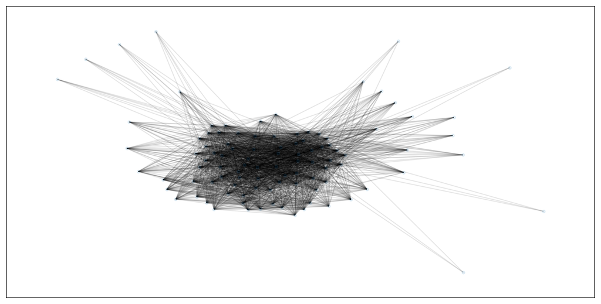

```python
# get the node IDs from G that contains the string efe4d5dd-fffb-41df-ab86-be06cc16646f_1_
# and get the subgraph of G that contains those nodes
nx.draw_networkx(
    G.subgraph([n for n in G.nodes if 'efe4d5dd-fffb-41df-ab86-be06cc16646f_1_' in n]),
    node_size = 10, with_labels = False, alpha = 0.1, linewidths = 1
)
```

Visualizing one of the clusters that have 13 SVs:

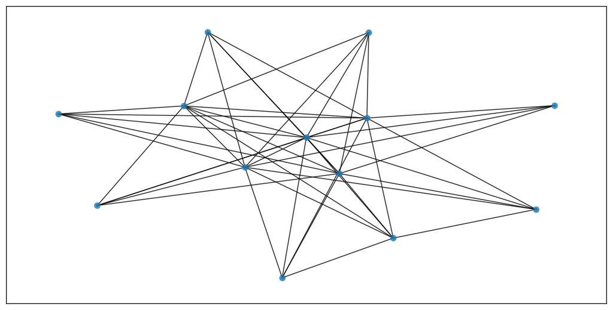

```python
# get the node IDs from G that contains the string efe4d5dd-fffb-41df-ab86-be06cc16646f_19_
# and get the subgraph of G that contains those nodes
nx.draw_networkx(
    G.subgraph([n for n in G.nodes if 'efe4d5dd-fffb-41df-ab86-be06cc16646f_19_' in n]),
    node_size = 10, with_labels = False, alpha = 0.8, linewidths = 4
)
```

```python
pickle.dump(G, open(workdir + "youyun/complexSV/data/networkx_test/test.txt", 'wb'))
```

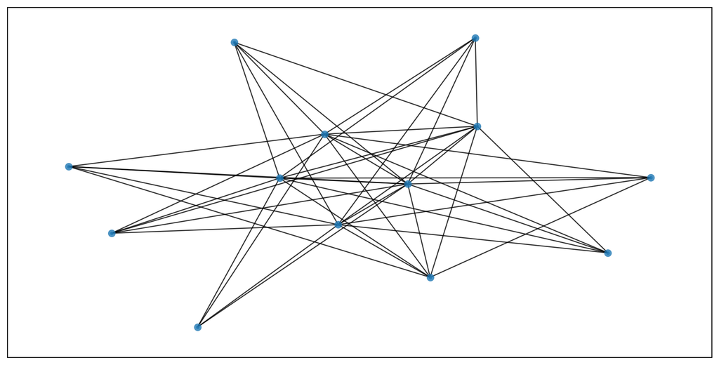

```python
G = pickle.load(open(workdir + "youyun/complexSV/data/networkx_test/test.txt", 'rb'))
nx.draw_networkx(
    G.subgraph([n for n in G.nodes if 'efe4d5dd-fffb-41df-ab86-be06cc16646f_19_' in n]),
    node_size = 10, with_labels = False, alpha = 0.8, linewidths = 4
)
```

```python
# relabel nodes by replacing 'Sample_cluster_ID_' with ''
G = nx.relabel_nodes(G, {n: n.replace('efe4d5dd-fffb-41df-ab86-be06cc16646f_19_', '') for n in G.nodes})
```